# rsibal_FinalHomeworkCode_05

Ritika

2023-11-17

# 1 Homework

## 1.1 When we initially discussed the central limit theorem and confidence intervals, we showed how we could use bootstrapping to estimate standard errors and confidence intervals around certain parameter values, like the mean. Using bootstrapping, we could also do the same for estimating standard errors and CIs around regression parameters, such as β coefficients.

## 1.2 Using the “KamilarAndCooperData.csv” dataset, run a linear regression looking at log(HomeRange_km2) in relation to log(Body_mass_female_mean) and report your β coeffiecients (slope and intercept).

```r
library(curl)
f <- curl("https://raw.githubusercontent.com/fuzzyatelin/fuzzyatelin.github.io/master/AN588_Fall23/KamilarAndCooperData.csv")
kandc_data <- read.csv(f, header = TRUE, sep = ",", stringsAsFactors = FALSE)
regression_line <- lm(formula = log(HomeRange_km2) ~ log(Body_mass_female_mean), data = kandc_data)
cat("slope=", regression_line[["coefficients"]][["log(Body_mass_female_mean)"]], "\n")
```

```
## slope= 1.036432
```

```r
cat("intercept=",regression_line[["coefficients"]][["(Intercept)"]])
```

```
## intercept= -9.441231
```

## 1.3 Then, use bootstrapping to sample from your data 1000 times with replacement, each time fitting the same model and calculating the same coefficients. This generates a sampling distribution for each β coefficient.

```r
library(dplyr)
slope_vector<-c()
intercept_vector<-c()

for (x in 1:1000){
  sample_kandc <- slice_sample(kandc_data, n = 30, replace = TRUE)
  regression_line_temp <- lm(formula = log(HomeRange_km2) ~ log(Body_mass_female_mean), data = sample_kandc)
  slope_vector <- c(slope_vector, regression_line_temp[["coefficients"]][["log(Body_mass_female_mean)"]])
  intercept_vector <- c(intercept_vector, regression_line_temp[["coefficients"]][["(Intercept)"]])
}
```

## 1.4 Estimate the standard error for each of your β coefficients as the standard deviation of the sampling distribution from your bootstrap and determine the 95% CI for each of your β coefficients based on the appropriate quantiles from your sampling distribution.

```r
# https://mgimond.github.io/Stats-in-R/CI.html

slope_mean <- mean(slope_vector)
slope_sd <- sd(slope_vector)
slope_ci <- slope_mean + qt( c(0.05, 0.95), length(slope_vector) - 1) * slope_sd
(list(slope_mean=slope_mean, slope_sd=slope_sd, slope_ci=slope_ci))
```

```
## $slope_mean
## [1] 1.059709
##
## $slope_sd
## [1] 0.241785
##
## $slope_ci
## [1] 0.6616389 1.4577791
```

```r
intercept_mean <- mean(intercept_vector)
intercept_sd <- sd(intercept_vector)
intercept_ci <- intercept_mean + qt( c(0.05, 0.95), length(intercept_vector) - 1) * intercept_sd
(list(intercept_mean=intercept_mean, intercept_sd=intercept_sd, intercept_ci=intercept_ci))
```

```
## $intercept_mean
## [1] -9.640825
##
## $intercept_sd
## [1] 1.90074
##
## $intercept_ci
## [1] -12.770166  -6.511483
```

## 1.5 How does the former compare to the SE estimated from your entire dataset using the formula for standard error implemented in lm()?

```r
summary(regression_line)
```

```
##
## Call:
## lm(formula = log(HomeRange_km2) ~ log(Body_mass_female_mean),
##     data = kandc_data)
##
## Residuals:
##     Min      1Q  Median      3Q     Max
## -3.3929 -0.9433 -0.0126  1.0944  3.6826
##
## Coefficients:
##                            Estimate Std. Error t value Pr(>|t|)
## (Intercept)                -9.44123    0.67293  -14.03   <2e-16 ***
## log(Body_mass_female_mean)  1.03643    0.08488   12.21   <2e-16 ***
## ---
## Signif. codes:  0 '***' 0.001 '**' 0.01 '*' 0.05 '.' 0.1 ' ' 1
##
## Residual standard error: 1.423 on 135 degrees of freedom
##   (76 observations deleted due to missingness)
## Multiple R-squared:  0.5248, Adjusted R-squared:  0.5213
## F-statistic: 149.1 on 1 and 135 DF,  p-value: < 2.2e-16
```

The standard error values estimated from lm() generally seem to much lower than what we computed in the previous section

## 1.6 How does the latter compare to the 95% CI estimated from your entire dataset?

```r
(confint(regression_line, level = 0.95))
```

```
##                                  2.5 %    97.5 %
## (Intercept)                -10.7720889 -8.110374
## log(Body_mass_female_mean)   0.8685707  1.204292
```

# 2 EXTRA CREDIT

## 2.1 Write a FUNCTION that takes as its arguments a dataframe, “d”, a linear model, “m” (as a character string, e.g., “logHR~logBM”), a user-defined confidence interval level, “conf.level” (with default = 0.95), and a number of bootstrap replicates, “n” (with default = 1000). Your function should return a dataframe that includes: beta coefficient names; beta coefficients, standard errors, and upper and lower CI limits for the linear model based on your entire dataset; and mean beta coefficient estimates, SEs, and CI limits for those coefficients based on your bootstrap.

```r
library(dplyr)

bootstrapping_vs_lm <- function(d, m, n=1000, conf.level=0.95){

# Split the string
y<-strsplit(m, split="~")[[1]][1]
x<-strsplit(m, split="~")[[1]][2]

# Bootstrapping Method
slope_vector<-c()
intercept_vector<-c()

for (x in 1:n){
  sample_data <- slice_sample(d, n = 30, replace = TRUE)
  regression_line_temp <- lm(formula = m, data = sample_data)
  slope_vector <- c(slope_vector, regression_line_temp[["coefficients"]][[2]])
  intercept_vector <- c(intercept_vector, regression_line_temp[["coefficients"]][["(Intercept)"]])
}

slope_mean <- mean(slope_vector)
slope_sd <- sd(slope_vector)
slope_ci <- slope_mean + qt( c(1-conf.level, conf.level), length(slope_vector) - 1) * slope_sd

intercept_mean <- mean(intercept_vector)
intercept_sd <- sd(intercept_vector)
intercept_ci <- intercept_mean + qt( c(1-conf.level, conf.level), length(intercept_vector) - 1) * intercept_sd

# Linear Model Method
regression_line <- lm(formula = m, data = d)

lm_slope_coefficent <- regression_line_temp[["coefficients"]][[2]]
lm_intercept_coefficent <- regression_line_temp[["coefficients"]][[1]]

temp_ci<-(confint(regression_line, level = 0.95))
lm_slope_ci <- c(temp_ci@.Data[2], temp_ci@.Data[4])
lm_intercept_ci <- c(temp_ci@.Data[1], temp_ci@.Data[3])

# From here: https://www.statology.org/extract-standard-error-from-lm-in-r/
lm_slope_SE=sqrt(diag(vcov(regression_line)))[2]
lm_intercept_SE=sqrt(diag(vcov(regression_line)))[1]

summary <- list(lm_slope_coefficent=lm_slope_coefficent,
                  lm_intercept_coefficent=lm_intercept_coefficent,
                  lm_slope_SE=lm_slope_SE,
                  lm_slope_ci=lm_slope_ci,
                  lm_intercept_SE=lm_intercept_SE,
                  lm_intercept_ci=lm_intercept_ci,
                  boot_slope_mean=slope_mean,
                  boot_slope_SE=slope_sd,
                  boot_slope_ci=slope_ci,
                  boot_intercept_mean=intercept_mean,
                  boot_intercept_SE=intercept_sd,
                  boot_intercept_ci=intercept_ci)
return(summary)

}
```

Now we check if our function works!

```r
bootstrapping_vs_lm(kandc_data, 'log(HomeRange_km2)~log(Body_mass_female_mean)')
```

```
## $lm_slope_coefficent
## [1] 1.238089
##
## $lm_intercept_coefficent
## [1] -11.26797
##
## $lm_slope_SE
## log(Body_mass_female_mean)
##                 0.08487709
##
## $lm_slope_ci
## [1] 0.8685707 1.2042923
##
## $lm_intercept_SE
## (Intercept)
##   0.6729346
##
## $lm_intercept_ci
## [1] -10.772089  -8.110374
##
## $boot_slope_mean
## [1] 1.039722
##
## $boot_slope_SE
## [1] 0.2324433
##
## $boot_slope_ci
## [1] 0.6570323 1.4224123
##
## $boot_intercept_mean
## [1] -9.497979
##
## $boot_intercept_SE
## [1] 1.819966
##
## $boot_intercept_ci
## [1] -12.494336  -6.501622
```

# 3 EXTRA EXTRA CREDIT

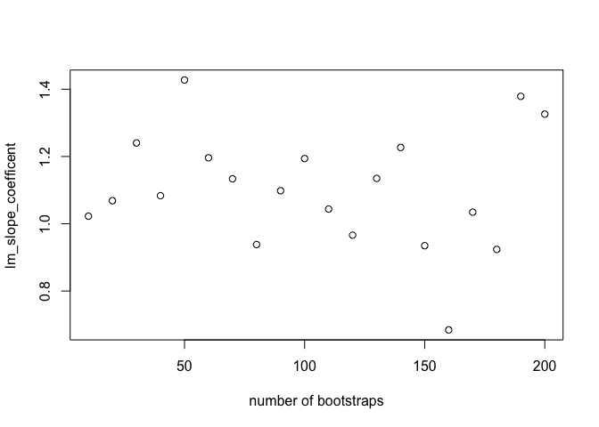

```r
n <- seq(10, 200, 10)

lm_slope_coefficent <- c()
boot_slope_mean <- c()
boot_slope_SE <- c()
boot_slope_ci_upper <- c()
boot_slope_ci_lower <- c()

lm_intercept_coefficent <-c()
boot_intercept_mean <- c()
boot_intercept_SE <- c()
boot_intercept_ci_upper <- c()
boot_intercept_ci_lower <- c()

for (x in n){
  data<-bootstrapping_vs_lm(kandc_data, 'log(HomeRange_km2)~log(Body_mass_female_mean)', n=x)
  lm_slope_coefficent <- c(lm_slope_coefficent, data$lm_slope_coefficent)
  boot_slope_mean <- c(boot_slope_mean, data$boot_slope_mean)
  boot_slope_SE <- c(boot_slope_SE, data$boot_slope_SE)
  boot_slope_ci_upper <- c(boot_slope_ci_upper, data$boot_slope_ci[2])
  boot_slope_ci_lower <- c(boot_slope_ci_lower, data$boot_slope_ci[1])

  lm_intercept_coefficent <- c(lm_intercept_coefficent, data$lm_intercept_coefficent)
  boot_intercept_mean <- c(boot_intercept_mean, data$boot_intercept_mean)
  boot_intercept_SE <- c(boot_intercept_SE, data$boot_intercept_SE)
  boot_intercept_ci_upper <- c(boot_intercept_ci_upper, data$boot_intercept_ci[1])
  boot_intercept_ci_lower <- c(boot_intercept_ci_lower, data$boot_intercept_ci[2])
}


plot(n, lm_slope_coefficent, xlab="number of bootstraps")
```

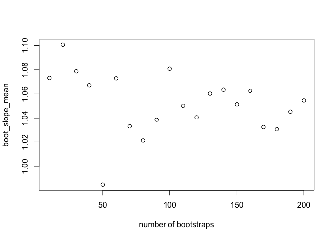

```r
plot(n, boot_slope_mean, xlab="number of bootstraps")
```

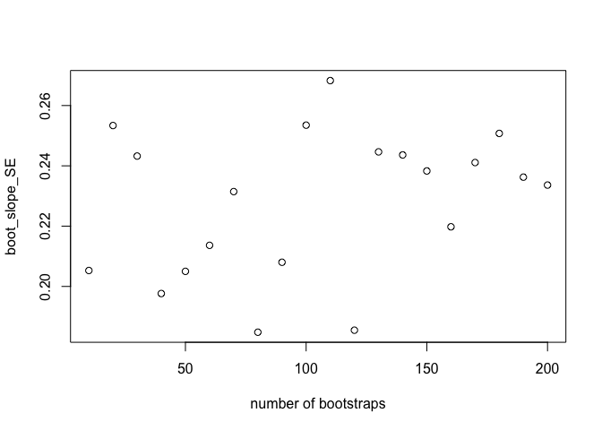

```r
plot(n, boot_slope_SE, xlab="number of bootstraps")
```

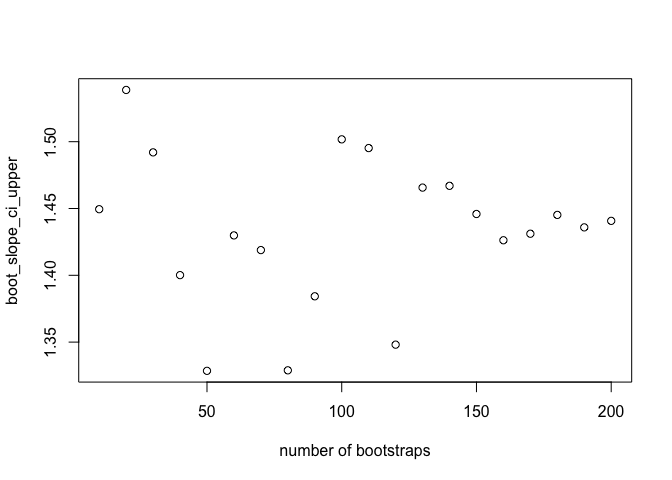

```r
plot(n, boot_slope_ci_upper, xlab="number of bootstraps")
```

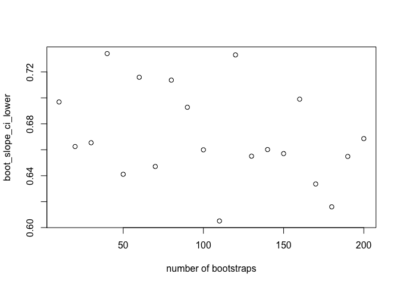

```r
plot(n, boot_slope_ci_lower, xlab="number of bootstraps")
```

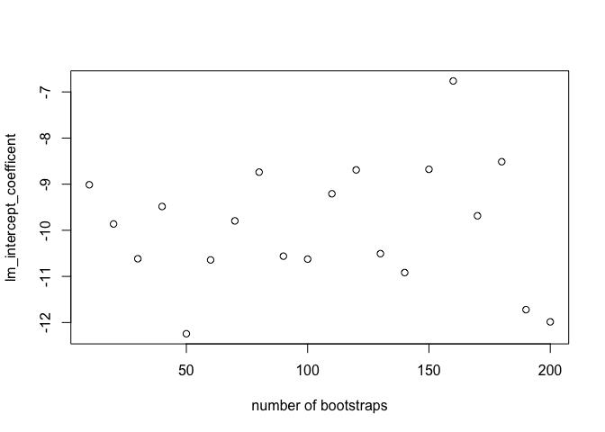

```r
plot(n, lm_intercept_coefficent, xlab="number of bootstraps")
```

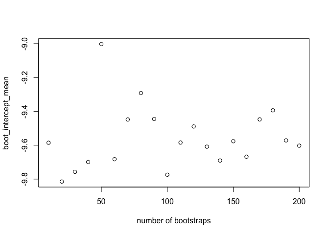

```r
plot(n, boot_intercept_mean, xlab="number of bootstraps")
```

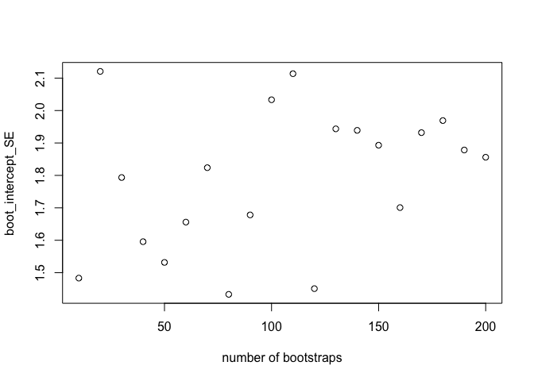

```r
plot(n, boot_intercept_SE, xlab="number of bootstraps")
```

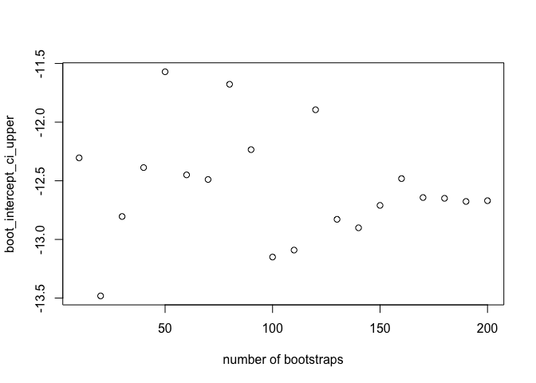

```r
plot(n, boot_intercept_ci_upper, xlab="number of bootstraps")
```

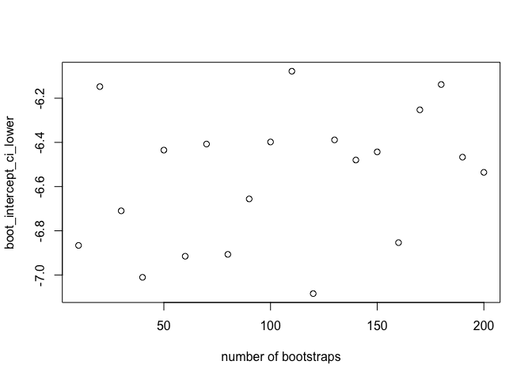

```r
plot(n, boot_intercept_ci_lower, xlab="number of bootstraps")
```

# 4 Reflection

**When I was coding:**

*3 things were difficult:*  
1) This homework is not too difficult to follow! I used a lot of code from previous homeworks to piece together the file.  
2) Indexing into the coefficient vectors was a little difficult for me! I ended up opening up the data and then clicking on the value I wanted to index–that gave me how to index it!  
3) Extracting the standard error from the lm() function was not very intuitive for me, I had to search for that answer online!

*How your peers commentary helped you:*  
1) My peer let me know that my code was easy to follow, which is always good to hear!

**When I was Peer Commentating:**

*2 things you liked in your peers code:*  
1) My peer used the HW3 solutions to do the bootstrapping method so I actually think it looked better than mine!  
2) My peer’s summary statements were really clear and nice to follow, and their output list was very aesthetic!

*1 thing that could use improvement:*  
1) Nothing really! My peer could have tried the extra credit if they wanted but that was it!